# Assignment 2. Databasing

Introduction to Data Science

9/24/2020

We’re going to be using event data harvested by Phil Schrodt (and a lot of C-code) from newswire stories about the Middle East. This event data has rows of the form

```
1979-04-15 ISRMIL JOR 190
```

which says that the Israeli military did an event of type 190 to Jordan. To understand what these events mean, there is a codebook with entries in the form

```
190 Use conventional military force, not specified below
```

Each such event type has a manually assigned conflict-cooperation score, described in another table with lines of the form

```
190 19 -10
```

which states that score 190 has ‘top level’ 19 (just the first two digits, indicating a coarser categorization) and is strongly negative -10. (The scale goes from -10 to 10.)

## Talking to the DB

First create a connection to the database file and ask for the names of the tables.

```r
library(DBI)
library(RSQLite)
con <- dbConnect(RSQLite::SQLite(), "levant.cameo.sqlite3")
dbListTables(con)
```

```
[1] "description"  "event"        "score"        "sqlite_stat1"
```

## Wrapping things up

There are three tables of interest (you don’t care about anything beginning `sqlite_`). And now you know what they are called, use `dplyr` to make them appear as if they were data.frames

```r
library(tidyverse) # loads the database backend for dplyr
event <- tbl(con, "event")
score <- tbl(con, "score")
desc <- tbl(con, "description")

event
```

```
# Source:   table<event> [?? x 4]
# Database: sqlite 3.36.0
#   [/Users/l.oswald/Desktop/assignment02/levant.cameo.sqlite3]
   date       source target code
   <chr>      <chr>  <chr>  <chr>
 1 1979-04-15 EGYGOV MOSREB 010
 2 1979-04-15 ISRMIL JOR    190
 3 1979-04-15 JOR    ISRMIL 190
 4 1979-04-15 EGY    IGOAMF 164
 5 1979-04-15 PALPLO ISR    015
 6 1979-04-15 GBR    ISRMIL 190
 7 1979-04-15 ISR    ISRMIL 190
 8 1979-04-15 ISR    EGYGOV 036
 9 1979-04-15 EGYGOV ISR    036
10 1979-04-15 ISRMIL PSEREB 190
# … with more rows
```

```r
# Note that we're not a data.frame 'really':
#
#   Source:   table<event> [?? x 4]"
#   Database: sqlite 3.34.0
```

## Scoring the events

To get conflict scores for events in this period, join the score table to the events table with a left join. Hint: think about which table should be left and why.

```r
scored_events <- left_join(event, score, by = "code") # add the 'by', to be sure

# parameter 1 ('event') is left and parameter 2 ('score') is right.
# We left left join so if there's an event in 'event' that has no corresponding
# score in 'score', we will assign it NA rather than throw it away (left_ retains
# all rows on the left (the 'event's), inner_ only retains rows with a 'code' on
# both sides, and right_ retains all rows on the right (the 'score's)
```

## Second Intifada

We can date the Second Intifada from 27th of September 2000 to 8th of February 2005. Create and name these two R dates (Hint: R works well with strings in ISO-standard date format) and use them to filter your copy of the events table to contain only events in the Second Intifada.

```r
# iso standard date notation
int_begin <- "2000-09-27"
int_end <- "2005-02-08"

int_event <- filter(scored_events, date >= int_begin & date <= int_end)
# we're using the fact that alphabetical order is an order
# that is: "1" < "11" < "2000-09-27" < "2000-10-01"
# iso-dates will work well for this kind of sorting.
#
# In real applications we'd most likely convert the variables to real dates,
# e.g. if we wanted to subtract dates to get durations, identify weekends, etc.

head(int_event) # still not a real data.frame!
```

```
# Source:   lazy query [?? x 6]
# Database: sqlite 3.36.0
#   [/Users/l.oswald/Desktop/assignment02/levant.cameo.sqlite3]
  date       source target code  toplevel score
  <chr>      <chr>  <chr>  <chr> <chr>    <dbl>
1 2000-09-27 SYRGOV IGOEEC 010   01         0
2 2000-09-27 PAL    USA    050   05         3.5
3 2000-09-27 USA    PAL    050   05         3.5
4 2000-09-27 ISRGOV ISR    020   02         3
5 2000-09-27 ISRGOV PAL    020   02         3
6 2000-09-27 ISRJUD ISRGOV 112   11        -2
```

Now `collect` the result so you have it as a regular R data.frame.

```r
real_int_event <- collect(int_event) # instantiate all rows in a real data.frame
head(real_int_event)
```

```
# A tibble: 6 × 6
  date       source target code  toplevel score
  <chr>      <chr>  <chr>  <chr> <chr>    <dbl>
1 2000-09-27 SYRGOV IGOEEC 010   01         0
2 2000-09-27 PAL    USA    050   05         3.5
3 2000-09-27 USA    PAL    050   05         3.5
4 2000-09-27 ISRGOV ISR    020   02         3
5 2000-09-27 ISRGOV PAL    020   02         3
6 2000-09-27 ISRJUD ISRGOV 112   11        -2
```

## Working in R

Next, filter it further to include only events where an source actor with name beginning ISR, e.g. ISRMIL or ISRGOV does something to a target actor beginning with PAL. You could use `filter` with `grepl` or a test of the first three letters. This is what conflict scholars call ‘the Israel-Palestine dyad’.

If you prefer, you could instead generate the Palestine-Israel dyad which tracks events done by Palestinian actors to Israeli actors.

```r
# Let's do PAL -> ISR
pal_isr <- filter(real_int_event,
                  grepl("^PAL", source) & grepl("ISR", target))

# alternative, less flexible version checking substring:
# pal_isr <- filter(real_int_event,
#                   (substring(source, 1, 3) == "PAL") &
#                    (substring(target, 1, 3) == "ISR"))
pal_isr
```

```
# A tibble: 962 × 6
   date       source target code  toplevel score
   <chr>      <chr>  <chr>  <chr> <chr>    <dbl>
 1 2000-09-28 PAL    ISRCOP 190   19       -10
 2 2000-09-28 PAL    ISRCOP 145   14        -7.5
 3 2000-09-29 PAL    ISR    190   19       -10
 4 2000-09-29 PAL    ISRCOP 190   19       -10
 5 2000-09-29 PAL    ISRGOV 050   05         3.5
 6 2000-09-30 PAL    ISRMIL 190   19       -10
 7 2000-10-01 PAL    ISR    141   14        -6.5
 8 2000-10-01 PAL    ISRMIL 190   19       -10
 9 2000-10-02 PAL    ISR    020   02         3
10 2000-10-02 PAL    ISRMIL 190   19       -10
# … with 952 more rows
```

## Time series

Finally we will visualize the conflict levels in this dyad. This will be less noisy if you aggregate temporally. To aggregate events by week, use cut. If your data.frame is called `evscore` and has a column called `date` then

```
evscore <- mutate(evscore,
  week = cut(as.Date(date), breaks = "week"),
  week = as.Date(as.character(week)))
```

where we have ensured date really is a date with `as.Date` (sometimes classes get mixed up in and out of databases), and created a nominal variable to represent dates that are in the same week using `cut.Date`. Then we have taken advantage of the fact that this variable is named after the date of the *first* day of the week it represents, so we can turn that into a character (it’s a factor label after `cut`), and then back into a proper date.

```r
pal_isr <- mutate(pal_isr,
                  week = cut(as.Date(date), breaks = "week"),
                  week = as.Date(as.character(week)))
head(pal_isr, 10)
```

```
# A tibble: 10 × 7
   date       source target code  toplevel score week
   <chr>      <chr>  <chr>  <chr> <chr>    <dbl> <date>
 1 2000-09-28 PAL    ISRCOP 190   19       -10   2000-09-25
 2 2000-09-28 PAL    ISRCOP 145   14        -7.5 2000-09-25
 3 2000-09-29 PAL    ISR    190   19       -10   2000-09-25
 4 2000-09-29 PAL    ISRCOP 190   19       -10   2000-09-25
 5 2000-09-29 PAL    ISRGOV 050   05         3.5 2000-09-25
 6 2000-09-30 PAL    ISRMIL 190   19       -10   2000-09-25
 7 2000-10-01 PAL    ISR    141   14        -6.5 2000-09-25
 8 2000-10-01 PAL    ISRMIL 190   19       -10   2000-09-25
 9 2000-10-02 PAL    ISR    020   02         3   2000-10-02
10 2000-10-02 PAL    ISRMIL 190   19       -10   2000-10-02
```

Lastly, average the score in each week of your dyad and plot the time series of conflict.

```r
# average scores by week
pal_isr_weekly <- summarise(group_by(pal_isr, week),
                            av_score = mean(score))
head(pal_isr_weekly)
```

[output not shown]

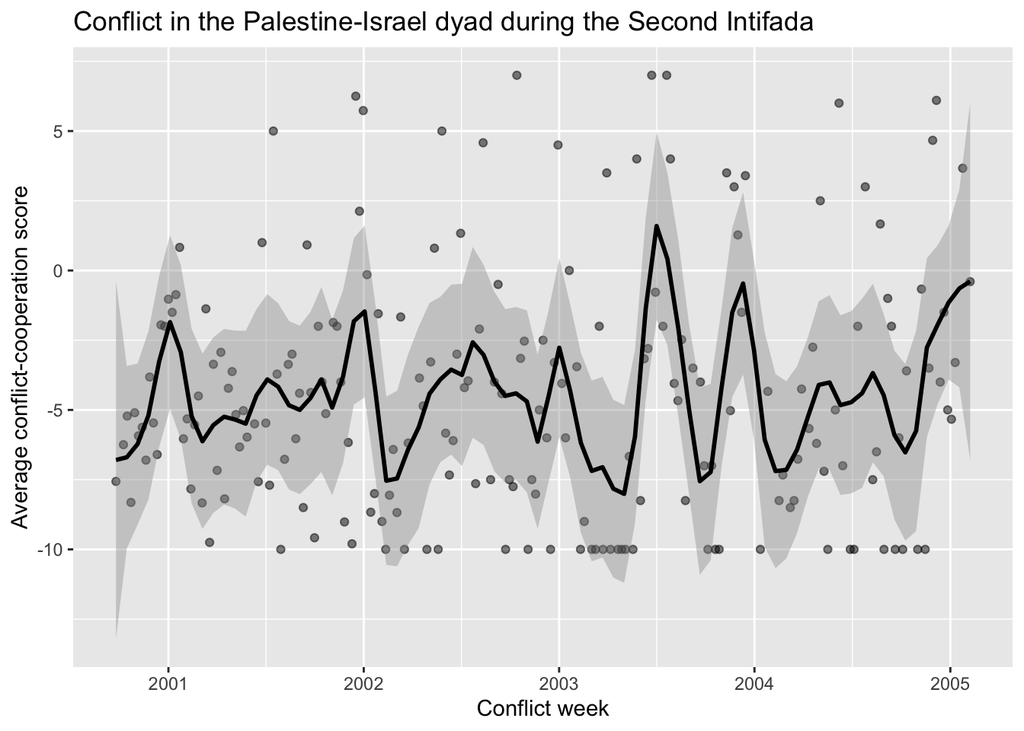

```r
# and plot as a time series
ggplot(pal_isr_weekly, aes(x = week, y = av_score)) +
  geom_point(alpha = 0.5) +
  geom_smooth(span = 0.1, colour = "black") +
  labs(x = "Conflict week",
       y = "Average conflict-cooperation score",
       title = "Conflict in the Palestine-Israel dyad during the Second Intifada")
```

```r
# Note: I've added a smooth line to pick out the structure (and also forced
# the smoother to smooth less vigorously by setting the span smaller than the default).
# You don't need to have done either - a line chart would have been fine
```

This is the kind of data and graphic that conflict forecasters use for prediction in governments around the world. And now we can do it too.

```r
# close our database connection now we don't need it anymore (not essential)
dbDisconnect(con)
```

## Handing it all in

This time around, just compile this document with code and answers and upload it to moodle. Specifically, I’ll be looking for a single knitted pdf, Word, or html file. I think that’s probably fancy enough, while we get used to the cloud business.